# Evaluation of the RESTful API for molar to mass concentration conversion using UCUM and LOINC

**Sam Tomioka**

**May 5, 2019**

## 1. Intruduction

The verification of scientific units and conversion from the reported units to standard units have been always challenging for Data Science due to several reasons:

1. Need a lookup table that consists of all possible input and output units for measurements, name of the measurements (e.g. Glucose, Weight, ...), conversion factors, molar weights etc.
2. The names of the measurement in the lookup table and incoming data must match
3. The incoming units must be in the lookup table
4. Maintenance of the lookup table must be synched with standard terminology update
5. Require careful medical review in addition to laborsome Data Science review and more...

Despite the challenges, the lookup table approach is the norm for many companies for verification of the units and conversion. Consideration was given for more systematic approach that does not require to use the lab test names[1], but some units rely on molar weight and/or valence of ion of the specific lab tests, so this approach does not solve the problem. The regulatory agencies require the sponsor to use standardized units for reporting and analysis[2]. The PMDA requires SI units for all reporting and analysis[3,4]. The differences in requirement force us to maintain region specific conversion for some measurements which add additional complexity.

The approach Jozef Aerts discussed uses RestAPI available through [Unified Code for Units of Measure (UCUM) Resources](https://ucum.nlm.nih.gov/ucum-lhc/index.html) which is maintained by the US National Library of Medicine (NLM)[5]. The benefit is obvious that we can potentially eliminate the maintenance of the lab conversion lookup table. Here is what they say about themselves.

> The Unified Code for Units of Measure (UCUM) is a code system intended to include all units of measures being contemporarily used in international science, engineering, and business. The purpose is to facilitate unambiguous electronic communication of quantities together with their units. The focus is on electronic communication, as opposed to communication between humans. A typical application of The Unified Code for Units of Measure are electronic data interchange (EDI) protocols, but there is nothing that prevents it from being used in other types of machine communication.

The UCUM is the ISO 11240 compliant standard and has been used in ICSR E2B submissions for regulators adopted ICH E2B(R3). [FDA requires the UCUM codes](https://www.fda.gov/industry/fda-resources-data-standards/units-measurement) for the [eVAERS ICSR E2B (R3) submissions](https://www.fda.gov/media/98617/download), [dosage strength in both content of product labeling](https://www.fda.gov/industry/fda-resources-data-standards/structured-product-labeling-resources) and [Drug Establishment Registration and Drug Listing](https://www.fda.gov/regulatory-information/search-fda-guidance-documents/providing-regulatory-submissions-electronic-format-drug-establishment-registration-and-drug-listing). UCUM codes have been adopted by HL7 [FHIR](https://www.hl7.org/fhir/terminologies-systems.html).

### 1-1 Introduction for mol-mass/mass-mol conversion

Jozef Aerts [announced](http://www.xml4pharma.com/UCUM/Instructions_for_testing_the_RESTful_web_service_for_molar_mass_unit_conversions.pdf) an updated RESTful API which accounts for the molecular weights of the analyte into the conversion between molar and mass concentrations. This additional functionality would facilitate the conversion of the lab results, verification of the standardized lab results and LOINC code provided by the vendors.

Although CDISC released a downloadable [CDISC UNIT and UCUM mapping xlsx file](https://www.cdisc.org/standards/terminology), this evaluation will not use it since the CDISC UNIT does not cover all reported units used by the clinical laboratory/bioanalytical/PK vendors. Regular expression along with UCUM unit validity service was used to convert and verify the units provided by the lab vendors. In the future, this will be done with encoder-decoder or transformer + sequence-to-sequence model which demonstrated near perfect to generate iso 8601 from numerous date formats.

An initial evaluation was done on RestAPI available through the [Unified Code for Units of Measure (UCUM) Resources](https://ucum.nlm.nih.gov/ucum-lhc/index.html) and the findings are summarized in 2-1. The second evaluation is completed on the test version of RestAPI provided by Jozef Aerts at [xml4pharma](http://www.xml4pharma.com/)

## 2 Findings

### 2-1 Prior Work

Previoiusly the production version of RestAPI provided by US National Library of Medicine was evaluated. See [here](https://stomioka.github.io/ucum/docs/usum_201902.html) for more detail.

**Table 1: Number of samples, and the results**

[output not shown]

2142 records were identified as error. Out of 2142 errors, 120 records identified as error due to having a categorical data despite unit was given. There were 2022 records where the source and target unit do not have the same property. Most of them are cause by lack of mass-mol conversions, and the rest appeared to be correct but medical judgement would be neccessary.

**Table 2: Summary of Error Messages**

| Type of Error | Records |
| --- | --- |
| ERROR: unexpected result: Error: Source and Target unit do not seem to belong to the same property | 2022 |
| ERROR: unexpected result: NEGATIVE is not a numeric value | 119 |
| ERROR: unexpected result: Negative is not a numeric value | 1 |

Overall, this approach worked for majority of the records 6458, however, a few improvements are required by NLM/NIH to full utilize this RestAPI.

1. Need for mass-mol conversions *
2. Need to account for valence of ion with respect to mEq to molar unit conversion
3. Need for an option to specify molar weight or LOINC code for accurate unit conversion with respect to molar unit.

### 2-2 Findings on Updated UCUM Conversion (May 2019)

A total of **419103** laboratory records were obtained from **17** clinical trials. Following steps were taken to reduce the number of records for the evaluation of a test version of UCUM Conversion API.

1. Removal of records with missing units before and after UCUM unit conversion
2. Removal of character type results such as ['Negative','None','Trace',...]
3. Removal of records does not require conversion. For example, the records with LBORRESU==LBSTRSU were removed.
4. Removal of duplicate records

**17384** records of laboratory results were used for the evaluation. This evaluation does not cover the use of MOLWEIGHT.

The **Table 3** below summarizes the number of records from each step.

**Table 3: Number of sample after each data clearning steps**

| - | Number of Records |
| --- | --- |
| Number of studies | 17 |
| Input data | 419103 |
| After removal of missing units before UCUM unit conversion | 276144 |
| After removal of character results | 255937 |
| After removal of records do not require conversion | 172205 |
| After removal of duplicate records* | 17550 |
| After removal of missing units after UCUM unit conversion | 17384 |

Note: *Dropped duplicates except for the first occurrence.

#### 2-2-1 Conversion Results

There were **2620** records from **27** tests where the LBSTRESN and UCUM conversion results did not match. Observed differences are plotted in **Section 4-1**.

Out of 27 tests,PHOS, TSH, and MG had a large difference between the LBSTRESN and UCUM conversion. PHOS (n=72) and TSH (n=139) had true positive findings. One test, MG (n=20), had false positive findings. In **Figure 1**, the left light colored bars show the LBSTRESN, and the right dark colored bars show the difference between LBSTRESN and the returned value from UCUM conversion. The details are discussed in Sec 4-1, but the **Table 4** summarizes the findings on these 3 tests.

[figure not shown]

**Figure 1: LBSTRESN and Difference between LBSTRESN and Return Value of UCUM Conversion**

**Table 4: Findings from the UCUM Conversion**

| LBTESTCD | Source of Issue | My Note |
| --- | --- | --- |
| MG | UCUM API | ion channel is ignored in conversion |
| PHOS | Input Data | mass-molar conversion was done incorrectly by the lab vendor |
| TSH | Input Data | mass-molar conversion was done incorrectly by the lab vendor |

#### 2-2-2 Error Messages from UCUM Conversion

7389 records were returned with error messages from UCUM Conversion as shown in the **Figure 2**. **Table 5** summarizes the type of errors received.

- The most frequent error was `ERROR: invalid double for Molecular Weight value = null` which turns out the be true positive finding. This is related to missing m.w. or LOINC when the conversion requires m.w..
- There were 9 kinds of `ERROR: No MW value for the LOINC code **xxxxxxx** is available or the LOINC code is invalid` . One of the error was due to invalid LOINC code `15153-0`, but the rest of errors appear to be due to missing m.w. in the LOINC database. It would be helpful if this error message is split into each condition (1. invalid LOINC code or missing MW in LOINC) for our verification purpose.
- Creatinine Clearance (mL/min/1.73 m2) conversion failed with `ERROR: number of annotations in source and target is different`. The surface area 1.73 m2 was added as annotation for the source but the target did not include the same annotation. This will be solve with http://xml4pharmaserver.com:8080/UCUMService2/rest/ucumtransform/121/from/mL/min/%7B1.73_m2%7D/to/mL/s/%7B1.73_m2%7D
- Several conversions failed with `ERROR: unexpected result: Error: Source and Target unit do not seem to belong to the same property`. See Table 6 for more detail.

[figure not shown]

**Figure 2: Error Messages by LBTESTCD**

**Table 5: Summary of Error Messages**

| Message | My Note | Sample Call |
| --- | --- | --- |
| ERROR: invalid double for Molecular Weight value = null | True positive finding | http://xml4pharmaserver.com:8080/UCUMService2/rest/ucumtransform/0.3/from/mg/dL/to/umol/L |
| ERROR: No MW value for the LOINC code 13457-7 is available or the LOINC code is invalid | Valid LOINC, No m.w from LOINC | http://xml4pharmaserver.com:8080/UCUMService2/rest/ucumtransform/103/from/mg/dL/to/mmol/L/LOINC/13457-7 |
| ERROR: No MW value for the LOINC code 15153-0 is available or the LOINC code is invalid | Invalid LOINC | http://xml4pharmaserver.com:8080/UCUMService2/rest/ucumtransform/0.3/from/mg/dL/to/umol/L/LOINC/15153-0 |
| ERROR: No MW value for the LOINC code 18262-6 is available or the LOINC code is invalid | Valid LOINC, No m.w from LOINC | http://xml4pharmaserver.com:8080/UCUMService2/rest/ucumtransform/118/from/mg/dL/to/mmol/L/LOINC/18262-6 |
| ERROR: No MW value for the LOINC code 1968-7 is available or the LOINC code is invalid | Valid LOINC, No m.w from LOINC | http://xml4pharmaserver.com:8080/UCUMService2/rest/ucumtransform/0.1/from/mg/dL/to/umol/L/LOINC/1968-7 |
| ERROR: No MW value for the LOINC code 3094-0 is available or the LOINC code is invalid | Valid LOINC, No m.w from LOINC | http://xml4pharmaserver.com:8080/UCUMService2/rest/ucumtransform/10/from/mg/dL/to/mmol/L/LOINC/3094-0 |
| ERROR: No MW value for the LOINC code 35192-4 is available or the LOINC code is invalid | Valid LOINC, No m.w from LOINC | http://xml4pharmaserver.com:8080/UCUMService2/rest/ucumtransform/1.07/from/mg/dL/to/umol/L/LOINC/35192-4 |
| ERROR: No MW value for the LOINC code 35197-3 is available or the LOINC code is invalid | Valid LOINC, No m.w from LOINC | http://xml4pharmaserver.com:8080/UCUMService2/rest/ucumtransform/85/from/mg/dL/to/mmol/L/LOINC/35197-3 |
| ERROR: No MW value for the LOINC code 35217-9 is available or the LOINC code is invalid | Valid LOINC, No m.w from LOINC | http://xml4pharmaserver.com:8080/UCUMService2/rest/ucumtransform/42/from/mg/dL/to/mmol/L/LOINC/35217-9 |
| ERROR: No MW value for the LOINC code 35234-4 is available or the LOINC code is invalid | Valid LOINC, No m.w from LOINC | http://xml4pharmaserver.com:8080/UCUMService2/rest/ucumtransform/12/from/mg/dL/to/mmol/L/LOINC/35234-4 |
| ERROR: number of annotations in source and target is different | ?? | http://xml4pharmaserver.com:8080/UCUMService2/rest/ucumtransform/121/from/mL/min/%7B1.73_m2%7D/to/mL/s |
| ERROR: unexpected result: Error: Source and Target unit do not seem to belong to the same property | Why the error is not 'ERROR: invalid double for Molecular Weight value = null' | http://xml4pharmaserver.com:8080/UCUMService2/rest/ucumtransform/12.9/from/uU/mL/to/pmol/L |

The following converions as listed in the **Table 6** returend the following error message.

> ERROR: unexpected result: Error: Source and Target unit do not seem to belong to the same property

**Table 6: List of unit conversions recieved error**

| LBTESTCD | LBORRESU | LBSTRESU |
| --- | --- | --- |
| INSULIN | uU/mL | pmol/L |
| BASO | G/L | 10*9/L |
| EOS | G/L | 10*9/L |
| LYM | G/L | 10*9/L |
| MONO | G/L | 10*9/L |
| NEUT | G/L | 10*9/L |
| PLAT | G/L | 10*9/L |
| RBC | T/L | 10*12/L |
| WBC | G/L | 10*9/L |
| LYMAT | G/L | 10*9/L |
| MYCY | G/L | 10*9/L |
| ALP | %5BIU%5D/L | U/L |
| ALT | %5BIU%5D/L | U/L |
| AST | %5BIU%5D/L | U/L |
| CK | %5BIU%5D/L | U/L |
| INSULIN | u%5BIU%5D/mL | pmol/L |

- `G` or `Giga per liter` is often used in the hematology panel and is equivalent to 10*9 as per ucum-essence.xml, but the conversion was not sucessful.
- `IU` and `U` are equivalent, but the conversion failed.
- `T` and `10*12' are equivalent as per ucum-essence.xml, but the conversion failed.

[output not shown]

Source:ucum-essence.xml

## Thought

This approach has potential and can be used for any units (PK, Lab, ECG, Vital Signs, etc). The addition of mass-mol/mol-mass conversion is a great addition and very useful to verify the results obtained from the vendors.

A few improvements would allow us to use this API at full potential. As previously discusses, the varence of an ion with respect to mEq to molar unit conversion was one of the issues. Some LOINC based conversion was not performed due to lack of m.w.. Conversion for units with `G`, `T`,`IU`, and `U` were not successful. 'ERROR: No MW value for the LOINC code xxxxxxx is available or the LOINC code is invalid' could be split into two errors for each condition for verification purpose. Otherwise, one need to lookup LOINC to confirm whether or not the LOINC is valid or m.w. is missing.

Overall, the tool was very useful and we found the conversion issues caused by two vendors affecting many clinical trials. We will implement this in SAS for programmers, and Python for automated checking using the production release by NIH.

[1] Wu and Wales (2017) [Laboratory Data Standardization with SAS](https://www.pharmasug.org/proceedings/2017/AD/PharmaSUG-2017-AD10.pdf) . PharmaSUG

[2] FDA (2013). [Position on Use of SI Units for Lab Tests - FDA](https://www.fda.gov/downloads/ForIndustry/DataStandards/StudyDataStandards/UCM587505.pdf)

[3] PMDA. (2015) [Notification on Practical Operations of Electronic Study Data Submissions](https://www.pmda.go.jp/files/000206451.pdf)

[4] PMDA (2017). [FAQs on Electronic Study Data Submission (Excerpt)](https://www.pmda.go.jp/english/review-services/reviews/advanced-efforts/0007.html)

[5] Jozef Aerts (2019) [SDTM --STRESN: why we need UCUM](http://cdiscguru.blogspot.com/2019/02/sdtm-stresn-why-we-need-ucum.html)

**Something to note:**

The units used in API call has to be compliant with the [USUM specifications](http://unitsofmeasure.org/ucum.html). In addition, URL encoding has to be applied for some special characters. URL encoding can be found [here](https://en.wikipedia.org/wiki/Percent-encoding).

## 3 Scripts

### 3-1 Initialization

```python
import boto3
import botocore
import re
import os
import pandas as pd
import pandas_profiling as pp
import pixiedust as px
import pickle
# Visual
%matplotlib inline

# my utilities
from lib.ucum import *

bucket='snvn-sagemaker-1' #data bucket
s3 = boto3.resource('s3')
url='http://xml4pharmaserver.com:8080/UCUMService2/rest'
```

```
Pixiedust database opened successfully
```

[figure not shown]

Pixiedust version 1.1.15

### 3-2 Copy data to notebook

```python
KEY=os.path.join('mldata','Sam','data','project','pool','lb.sas7bdat')
os.makedirs('data', exist_ok=True)

try:
    s3.Bucket(bucket).download_file(KEY, os.path.join('data','sdtm_lb.sas7bdat'))
except botocore.exceptions.ClientError as e:
    if e.response['Error']['Code'] == "404":
        print("The object does not exist.")
    else:
        raise
```

### 3-3 Retain records for verification

```python
rlb=pd.read_sas('data/raw_lb.sas7bdat',encoding='latin')
print('Number of studies: ',len(list(set(rlb['STUDYID']))))
df=rlb[['LBTESTCD','LBTEST','LBORRES','LBORRESU','LBSTRESU','LBSTRESN','LBLOINC']]
#df=df[df['LBORRESU']!='LBSTRESU'] #since we don't need to verify
print('Number of records in the input: ',df.shape)

#Cleaning Input Data
df1=df.copy()
df1.dropna(axis=0, subset=['LBORRESU'], inplace=True)
df1.dropna(axis=0, subset=['LBSTRESU'], inplace=True)
#df1['ge']=df1['LBORRES'].str.findall(r'<|>=')
#df1['LBORRES']=df1['LBORRES'].str.replace(r'<','')
#df1['LBORRES']=df1['LBORRES'].str.replace(r'>=','')
print('Removed records with missing units: ', df1.shape)
#Remove records not needed for verification
#1. results contain character
df1['LBORRES']=df1['LBORRES'].str.replace(r'[a-zA-Z ]+','')
df1=df1[df1['LBORRES']!='']
df1.dropna(axis=0, subset=['LBSTRESN'], inplace=True)

print('Removed records with character results: ',df1.shape)
#2. both units are the same
df1=df1[df1['LBORRESU']!=df1['LBSTRESU']]
print('Removed records do not require conversion: ',df1.shape)
df1.to_csv('lb.csv')
```

```
Number of studies:  17
Number of records in the input:  (419103, 7)
Removed records with missing units:  (276144, 7)
Removed records with character results:  (255937, 7)
Removed records do not require conversion:  (172205, 7)
```

Let's see what units have been used in the input datasets

```
(<module 'matplotlib.pyplot' from '/home/ec2-user/anaconda3/envs/python3/lib/python3.6/site-packages/matplotlib/pyplot.py'>,
```

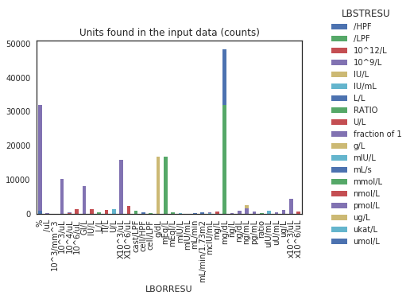

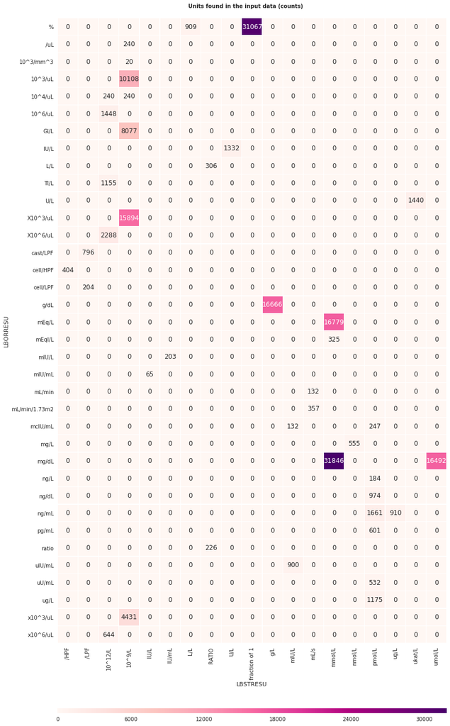

```python
bar_hm(df1,'Units found in the input data (counts)')
```

### 3-4 Define regular expression used to convert the input units to UCUM

```python
#Regular expressions. --- update this based on raw data
patterns = [("%","%25"),
           ("\A[xX]?10[^E]", "10*"),
           ("IU", "%5BIU%5D"),
           ("\Anan", ""),
           ("\ANONE", ""),
           ("\A[rR][Aa][Tt][Ii][Oo]", ""),
           ("\ApH", ""),
           ("Eq[l]?","eq"),
           ("\ATI/L","T/L"),
           ("\AGI/L","G/L"),
           ("V/V","L/L"),
           ("[a-z]{0,4}/HPF","/%5BHPF%5D"),
           ("[a-z]{0,4}/LPF","/%5BLPF%5D"),
           ("fraction of 1","1"),
            ("sec","s"),
            ("1.73m2","%7B1.73_m2%7D")
           ]
```

### 3-5 Functions used

1. cleanlist: a helper function which takes the elements of patterns to output UCUM conformant unit
2. orresu2ucum: a function which takes the dataframe containing LBORRESU and LBSTRESU, and apply `cleanlist`
3. ucumVerify: a function which takes the list of units to verify the conformance to UCUM using `isValidUCUM` and returns a list with either True or False.
4. convert_unit: a function which takes the dataframe containing LBORRESU and LBSTRESU in UCUM and returns a dataframe where original LBSTRESN is not equal to LBSTRESN from the [UCUM-LHC Converter](https://ucum.nlm.nih.gov/ucum-lhc/demo.html)

### 3-6 Verify converted UCUM

```python
dfconverted, ucumlist=orresu2ucum(df1,patterns)
ucumVerify(ucumlist, url)
```

```
['g/dL = true',
 'mg/dL = true',
 'ng/mL = true',
 '10*3/uL = true',
 '%25 = true',
 '10*6/uL = true',
 '10*3/mm3 = true',
 'meq/L = true',
 'mL/min = true',
 'ng/L = true',
 'ng/dL = true',
 'u%5BIU%5D/mL = true',
 '10*3/uL = true',
 '10*6/uL = true',
 'uU/mL = true',
 'mg/L = true',
 'meq/L = true',
 'G/L = true',
 'ug/L = true',
 'T/L = true',
 'm%5BIU%5D/mL = true',
 '10*3/uL = true',
 '10*6/uL = true',
 'pg/mL = true',
 '%5BIU%5D/L = true',
 'U/L = true',
 '10*4/uL = true',
 '/uL = true',
 'L/L = true',
 'm%5BIU%5D/L = true',
 '/%5BLPF%5D = true',
 '/%5BLPF%5D = true',
 '/%5BHPF%5D = true',
 'mL/min/%7B1.73_m2%7D = true',
 'u%5BIU%5D/mL = true',
 'g/L = true',
 'umol/L = true',
 'mmol/L = true',
 '10*9/L = true',
 '10*12/L = true',
 'mL/s = true',
 '1 = true',
 'pmol/L = true',
 'nmol/L = true',
 'ukat/L = true',
 '%5BIU%5D/mL = true',
 '/%5BLPF%5D = true',
 '/%5BHPF%5D = true']
```

```
(<module 'matplotlib.pyplot' from '/home/ec2-user/anaconda3/envs/python3/lib/python3.6/site-packages/matplotlib/pyplot.py'>,
```

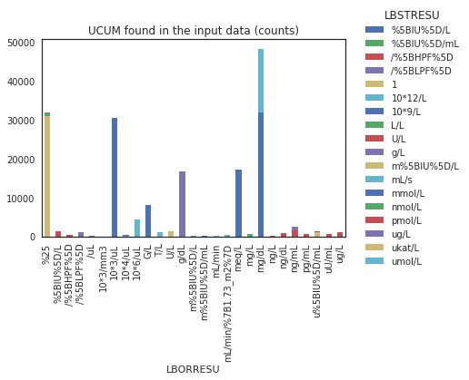

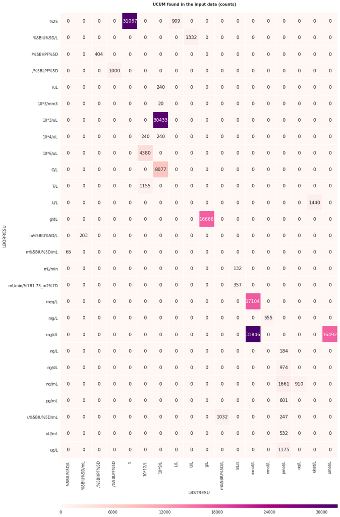

```python
bar_hm(dfconverted,'UCUM found in the input data (counts)')
```

### 3-7 Verify Conversion

```python
nodupdf=df1.drop_duplicates(subset=['LBTESTCD','LBORRESU','LBORRES','LBSTRESN','LBSTRESU'], keep='first')
print('Removed duplicate records: ', nodupdf.shape[0])
```

```
Removed duplicate records:  17550
```

```python
if os.path.isfile('output/findings.pickle'):
    findings= open('output/findings.pickle', mode='rb')
    findings=pickle.load(findings)
    full= open('output/full.pickle', mode='rb')
    full=pickle.load(full)
    response= open('output/response.pickle', mode='rb')
    response=pickle.load(response)
else:
    findings,full,response=convert_unit(nodupdf, url, patterns,loinconly=0)
```

```python
with open('output/findings.pickle', 'wb') as handle:
    pickle.dump(findings, handle, protocol=pickle.HIGHEST_PROTOCOL)
with open('output/full.pickle', 'wb') as handle:
    pickle.dump(full, handle, protocol=pickle.HIGHEST_PROTOCOL)
with open('output/response.pickle', 'wb') as handle:
    pickle.dump(response, handle, protocol=pickle.HIGHEST_PROTOCOL)
```

## 4 Output Issues

### 4-1 Discrepancies between LBSTRESN and Conversion based on UCUM

```python
findings[(findings['fromucum'].notnull())]
```

|  | LBTESTCD | LBTEST | LBORRES | LBORRESU | LBSTRESU | LBSTRESN | LBLOINC | checklist | fromucum | response |
| --- | --- | --- | --- | --- | --- | --- | --- | --- | --- | --- |
| 1 | BILI | Bilirubin | 0.4 | mg/dL | umol/L | 6.00 | 1975-2 | http://xml4pharmaserver.com:8080/UCUMService2/... | 6.841431 | None |
| 2 | CREAT | Creatinine | 0.96 | mg/dL | umol/L | 85.00 | 2160-0 | http://xml4pharmaserver.com:8080/UCUMService2/... | 84.865629 | None |
| 4 | GLUC | Glucose | 92 | mg/dL | mmol/L | 5.10 | 2345-7 | http://xml4pharmaserver.com:8080/UCUMService2/... | 5.106685 | None |
| 6 | URATE | Urate | 4.5 | mg/dL | mmol/L | 0.27 | 3084-1 | http://xml4pharmaserver.com:8080/UCUMService2/... | 0.267679 | None |
| 21 | BILI | Bilirubin | 0.6 | mg/dL | umol/L | 10.00 | 1975-2 | http://xml4pharmaserver.com:8080/UCUMService2/... | 10.262147 | None |
| 22 | CREAT | Creatinine | 1.01 | mg/dL | umol/L | 89.00 | 2160-0 | http://xml4pharmaserver.com:8080/UCUMService2/... | 89.285714 | None |
| 24 | GLUC | Glucose | 88 | mg/dL | mmol/L | 4.90 | 2345-7 | http://xml4pharmaserver.com:8080/UCUMService2/... | 4.884656 | None |
| 26 | URATE | Urate | 5.0 | mg/dL | mmol/L | 0.30 | 3084-1 | http://xml4pharmaserver.com:8080/UCUMService2/... | 0.297421 | None |
| 38 | BILI | Bilirubin | 0.2 | mg/dL | umol/L | 4.00 | 1975-2 | http://xml4pharmaserver.com:8080/UCUMService2/... | 3.420716 | None |
| 39 | CREAT | Creatinine | 0.87 | mg/dL | umol/L | 77.00 | 2160-0 | http://xml4pharmaserver.com:8080/UCUMService2/... | 76.909477 | None |
| 42 | URATE | Urate | 4.4 | mg/dL | mmol/L | 0.26 | 3084-1 | http://xml4pharmaserver.com:8080/UCUMService2/... | 0.261730 | None |
| 54 | BILI | Bilirubin | 0.6 | mg/dL | umol/L | 11.00 | 1975-2 | http://xml4pharmaserver.com:8080/UCUMService2/... | 10.262147 | None |
| 55 | GLUC | Glucose | 113 | mg/dL | mmol/L | 6.30 | 2345-7 | http://xml4pharmaserver.com:8080/UCUMService2/... | 6.272342 | None |
| 56 | URATE | Urate | 3.9 | mg/dL | mmol/L | 0.23 | 3084-1 | http://xml4pharmaserver.com:8080/UCUMService2/... | 0.231988 | None |
| 65 | CREAT | Creatinine | 0.86 | mg/dL | umol/L | 76.00 | 2160-0 | http://xml4pharmaserver.com:8080/UCUMService2/... | 76.025460 | None |
| 66 | GLUC | Glucose | 86 | mg/dL | mmol/L | 4.80 | 2345-7 | http://xml4pharmaserver.com:8080/UCUMService2/... | 4.773641 | None |
| 67 | URATE | Urate | 6.2 | mg/dL | mmol/L | 0.37 | 3084-1 | http://xml4pharmaserver.com:8080/UCUMService2/... | 0.368802 | None |
| 78 | CREAT | Creatinine | 0.81 | mg/dL | umol/L | 72.00 | 2160-0 | http://xml4pharmaserver.com:8080/UCUMService2/... | 71.605375 | None |
| 79 | GLUC | Glucose | 117 | mg/dL | mmol/L | 6.50 | 2345-7 | http://xml4pharmaserver.com:8080/UCUMService2/... | 6.494371 | None |
| 91 | BILI | Bilirubin | 0.4 | mg/dL | umol/L | 7.00 | 1975-2 | http://xml4pharmaserver.com:8080/UCUMService2/... | 6.841431 | None |
| 92 | CREAT | Creatinine | 0.95 | mg/dL | umol/L | 84.00 | 2160-0 | http://xml4pharmaserver.com:8080/UCUMService2/... | 83.981612 | None |
| 93 | GLUC | Glucose | 85 | mg/dL | mmol/L | 4.70 | 2345-7 | http://xml4pharmaserver.com:8080/UCUMService2/... | 4.718133 | None |
| 95 | URATE | Urate | 5.7 | mg/dL | mmol/L | 0.34 | 3084-1 | http://xml4pharmaserver.com:8080/UCUMService2/... | 0.339060 | None |
| 103 | CREAT | Creatinine | 1.05 | mg/dL | umol/L | 93.00 | 2160-0 | http://xml4pharmaserver.com:8080/UCUMService2/... | 92.821782 | None |
| 105 | GLUC | Glucose | 95 | mg/dL | mmol/L | 5.30 | 2345-7 | http://xml4pharmaserver.com:8080/UCUMService2/... | 5.273208 | None |
| 107 | URATE | Urate | 6.7 | mg/dL | mmol/L | 0.40 | 3084-1 | http://xml4pharmaserver.com:8080/UCUMService2/... | 0.398544 | None |
| 116 | BILI | Bilirubin | 0.3 | mg/dL | umol/L | 5.00 | 1975-2 | http://xml4pharmaserver.com:8080/UCUMService2/... | 5.131073 | None |
| 117 | CREAT | Creatinine | 1.03 | mg/dL | umol/L | 91.00 | 2160-0 | http://xml4pharmaserver.com:8080/UCUMService2/... | 91.053748 | None |
| 120 | URATE | Urate | 4.9 | mg/dL | mmol/L | 0.29 | 3084-1 | http://xml4pharmaserver.com:8080/UCUMService2/... | 0.291472 | None |
| 134 | BILI | Bilirubin | 0.2 | mg/dL | umol/L | 3.00 | 1975-2 | http://xml4pharmaserver.com:8080/UCUMService2/... | 3.420716 | None |
| ... | ... | ... | ... | ... | ... | ... | ... | ... | ... | ... |
| 17229 | NEUTLE | Neutrophils/Leukocytes | 56.3 | %25 | 1 | 0.56 | 770-8 | http://xml4pharmaserver.com:8080/UCUMService2/... | 0.563000 | None |
| 17235 | NEUTLE | Neutrophils/Leukocytes | 56.7 | %25 | 1 | 0.57 | 770-8 | http://xml4pharmaserver.com:8080/UCUMService2/... | 0.567000 | None |
| 17248 | BASOLE | Basophils/Leukocytes | 0.1 | %25 | 1 | 0.00 | 706-2 | http://xml4pharmaserver.com:8080/UCUMService2/... | 0.001000 | None |
| 17249 | NEUTLE | Neutrophils/Leukocytes | 64.9 | %25 | 1 | 0.65 | 770-8 | http://xml4pharmaserver.com:8080/UCUMService2/... | 0.649000 | None |
| 17252 | NEUTLE | Neutrophils/Leukocytes | 49.1 | %25 | 1 | 0.49 | 770-8 | http://xml4pharmaserver.com:8080/UCUMService2/... | 0.491000 | None |
| 17254 | LYMLE | Lymphocytes/Leukocytes | 33.8 | %25 | 1 | 0.34 | 736-9 | http://xml4pharmaserver.com:8080/UCUMService2/... | 0.338000 | None |
| 17259 | NEUTLE | Neutrophils/Leukocytes | 63.5 | %25 | 1 | 0.64 | 770-8 | http://xml4pharmaserver.com:8080/UCUMService2/... | 0.635000 | None |
| 17264 | LYMLE | Lymphocytes/Leukocytes | 14.3 | %25 | 1 | 0.14 | 736-9 | http://xml4pharmaserver.com:8080/UCUMService2/... | 0.143000 | None |
| 17267 | NEUTLE | Neutrophils/Leukocytes | 75.4 | %25 | 1 | 0.75 | 770-8 | http://xml4pharmaserver.com:8080/UCUMService2/... | 0.754000 | None |
| 17281 | EOSLE | Eosinophils/Leukocytes | 7.7 | %25 | 1 | 0.08 | 713-8 | http://xml4pharmaserver.com:8080/UCUMService2/... | 0.077000 | None |
| 17283 | LYMLE | Lymphocytes/Leukocytes | 23.2 | %25 | 1 | 0.23 | 736-9 | http://xml4pharmaserver.com:8080/UCUMService2/... | 0.232000 | None |
| 17287 | CHOL | Cholesterol | 273 | mg/dL | mmol/L | 7.07 | 2093-3 | http://xml4pharmaserver.com:8080/UCUMService2/... | 7.060393 | None |
| 17296 | NEUTLE | Neutrophils/Leukocytes | 50.7 | %25 | 1 | 0.51 | 770-8 | http://xml4pharmaserver.com:8080/UCUMService2/... | 0.507000 | None |
| 17302 | NEUTLE | Neutrophils/Leukocytes | 71.3 | %25 | 1 | 0.71 | 770-8 | http://xml4pharmaserver.com:8080/UCUMService2/... | 0.713000 | None |
| 17305 | LYMLE | Lymphocytes/Leukocytes | 21.1 | %25 | 1 | 0.21 | 736-9 | http://xml4pharmaserver.com:8080/UCUMService2/... | 0.211000 | None |
| 17306 | NEUTLE | Neutrophils/Leukocytes | 71.8 | %25 | 1 | 0.72 | 770-8 | http://xml4pharmaserver.com:8080/UCUMService2/... | 0.718000 | None |
| 17312 | CRP | C Reactive Protein | 49.5 | mg/L | nmol/L | 471.40 | 30522-7 | http://xml4pharmaserver.com:8080/UCUMService2/... | 471.428570 | None |
| 17316 | NEUTLE | Neutrophils/Leukocytes | 64.1 | %25 | 1 | 0.64 | 770-8 | http://xml4pharmaserver.com:8080/UCUMService2/... | 0.641000 | None |
| 17319 | LYMLE | Lymphocytes/Leukocytes | 35.4 | %25 | 1 | 0.35 | 736-9 | http://xml4pharmaserver.com:8080/UCUMService2/... | 0.354000 | None |
| 17322 | LYMLE | Lymphocytes/Leukocytes | 23.3 | %25 | 1 | 0.23 | 736-9 | http://xml4pharmaserver.com:8080/UCUMService2/... | 0.233000 | None |
| 17326 | LYMLE | Lymphocytes/Leukocytes | 34.5 | %25 | 1 | 0.35 | 736-9 | http://xml4pharmaserver.com:8080/UCUMService2/... | 0.345000 | None |
| 17331 | NEUTLE | Neutrophils/Leukocytes | 48.1 | %25 | 1 | 0.48 | 770-8 | http://xml4pharmaserver.com:8080/UCUMService2/... | 0.481000 | None |
| 17334 | LYMLE | Lymphocytes/Leukocytes | 47.2 | %25 | 1 | 0.47 | 736-9 | http://xml4pharmaserver.com:8080/UCUMService2/... | 0.472000 | None |
| 17339 | LYMLE | Lymphocytes/Leukocytes | 22.9 | %25 | 1 | 0.23 | 736-9 | http://xml4pharmaserver.com:8080/UCUMService2/... | 0.229000 | None |
| 17344 | EOSLE | Eosinophils/Leukocytes | 6.8 | %25 | 1 | 0.07 | 713-8 | http://xml4pharmaserver.com:8080/UCUMService2/... | 0.068000 | None |
| 17349 | NEUTLE | Neutrophils/Leukocytes | 40.9 | %25 | 1 | 0.41 | 770-8 | http://xml4pharmaserver.com:8080/UCUMService2/... | 0.409000 | None |
| 17355 | NEUTLE | Neutrophils/Leukocytes | 55.1 | %25 | 1 | 0.55 | 770-8 | http://xml4pharmaserver.com:8080/UCUMService2/... | 0.551000 | None |
| 17369 | NEUTLE | Neutrophils/Leukocytes | 38.9 | %25 | 1 | 0.39 | 770-8 | http://xml4pharmaserver.com:8080/UCUMService2/... | 0.389000 | None |
| 17376 | LYMLE | Lymphocytes/Leukocytes | 41.6 | %25 | 1 | 0.42 | 736-9 | http://xml4pharmaserver.com:8080/UCUMService2/... | 0.416000 | None |
| 17379 | RDW | Erythrocytes Distribution Width | 16.7 | %25 | 1 | 0.17 | 788-0 | http://xml4pharmaserver.com:8080/UCUMService2/... | 0.167000 | None |

2620 rows × 10 columns

```python
discrepant=findings[(findings['fromucum'].notnull())]
diff=discrepant.copy()
diff['diff']=np.array(discrepant['LBSTRESN'])-np.array(discrepant['fromucum'])
diff.dropna(axis=0, how='any',subset=['diff'], inplace=True)
dfpiv=diff.pivot(columns='LBTESTCD', values='diff')
difftests=len(dfpiv.columns)
#dfpiv.describe()
```

**Check differences between reported LBSTRESN vs Converted Results**

```python
discrepant0=diff.groupby(by=['LBTESTCD','LBSTRESU'],as_index =True)
discrepant0=discrepant0.describe().xs('mean', level=1, axis=1)[['LBSTRESN','diff']]
discrepant1=pd.melt(discrepant0.reset_index(), id_vars=['LBTESTCD','LBSTRESU'],value_vars=['LBSTRESN','diff'])
```

[figure not shown]

```python
g = sns.FacetGrid(discrepant1, col='LBSTRESU', row='LBTESTCD', sharey='row', margin_titles=True)
g.map(sns.barplot, 'LBTESTCD', 'value', 'variable', hue_order=['LBSTRESN','diff'], alpha=.8)
```

```python
discrepant2=discrepant1[discrepant1['LBTESTCD'].isin(['MG','PHOS','TSH'])]
```

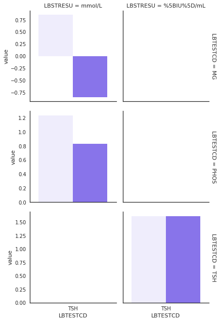

```python
g = sns.FacetGrid(discrepant2, col='LBSTRESU', row='LBTESTCD', sharey='row', margin_titles=True)
g.map(sns.barplot, 'LBTESTCD', 'value', 'variable', hue_order=['LBSTRESN','diff'], alpha=.8)
```

**Note:** Issues were identified in MG, PHOS, and TSH. Other differences are neglibile.

```python
#pp.ProfileReport(dfpiv)
#px.display(dfpiv)
```

```python
import random
c_=[]
for i in range(27):
    r = lambda: random.randint(0,255)
    c='#%02X%02X%02X' % (r(),r(),r())
    c_.append(c)
```

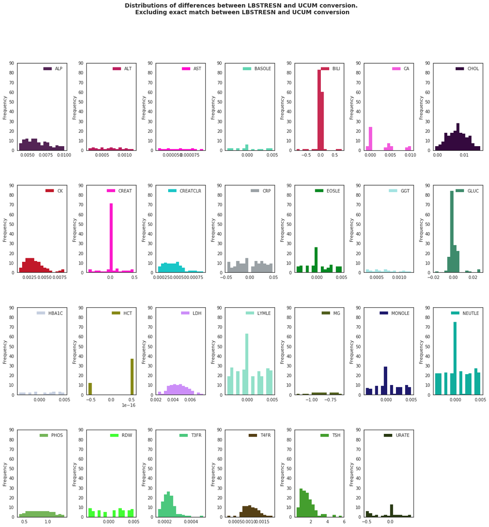

```python
fig = plt.figure( figsize=(20,20))
fig.subplots_adjust(hspace=0.4, wspace=0.4)

idx = np.arange(1, difftests+1)
for i, col, c in zip(idx, dfpiv.columns, c_):
    ax = fig.add_subplot(4, 7, i)
    #dfpiv.loc[:, col].plot.hist(label=col, color=c, range=(diff['diff'].min(), diff['diff'].max()), bins=15)
    dfpiv.loc[:, col].plot.hist(label=col, color=c,  bins=15)
    plt.yticks(np.arange(0, 100, 10))
    plt.suptitle('Distributions of differences between LBSTRESN and UCUM conversion. \nExcluding exact match between LBSTRESN and UCUM conversion', fontsize=14, fontweight='bold')


    plt.legend()
```

### 4-1-1 $\text{Mg}^{+2}$

```python
check=sumstat('MG',findings, rlb, dfpiv)
```

```
MG: Summary stats of LBSTRESN

         LBSTRESN
            count      mean       std   min  25%   50%  75%  max
LBSTRESU
mmol/L     5397.0  0.851776  0.070848  0.43  0.8  0.85  0.9  1.2
--------------------------------------------------------------
MG: Summary stats of UCUM Conversion

         fromucum
            count   mean       std  min    25%  50%    75%  max
LBSTRESU
mmol/L       20.0  1.715  0.326505  1.2  1.475  1.7  1.925  2.4
--------------------------------------------------------------
MG: Summary stats of Differences between LBSTRESN and UCUM Conversion

count    20.000000
mean     -0.857500
std       0.163252
min      -1.200000
25%      -0.962500
50%      -0.850000
75%      -0.737500
max      -0.600000
Name: MG, dtype: float64
```

```python
check.head()
```

|  | LBTESTCD | LBTEST | LBORRES | LBORRESU | LBSTRESU | LBSTRESN | LBLOINC | checklist | fromucum | response |
| --- | --- | --- | --- | --- | --- | --- | --- | --- | --- | --- |
| 1945 | MG | Magnesium | 1.6 | meq/L | mmol/L | 0.80 | 54919-6 | http://xml4pharmaserver.com:8080/UCUMService2/... | 1.6 | None |
| 1946 | MG | Magnesium | 1.7 | meq/L | mmol/L | 0.85 | 54919-6 | http://xml4pharmaserver.com:8080/UCUMService2/... | 1.7 | None |
| 1985 | MG | Magnesium | 1.5 | meq/L | mmol/L | 0.75 | 54919-6 | http://xml4pharmaserver.com:8080/UCUMService2/... | 1.5 | None |
| 2015 | MG | Magnesium | 1.8 | meq/L | mmol/L | 0.90 | 54919-6 | http://xml4pharmaserver.com:8080/UCUMService2/... | 1.8 | None |
| 2045 | MG | Magnesium | 1.9 | meq/L | mmol/L | 0.95 | 54919-6 | http://xml4pharmaserver.com:8080/UCUMService2/... | 1.9 | None |

**Note:** The error is originated from UCUM API. Ion channel of the $\text{Mg}^{+2}$ was not been considered.

### 4-1-2 PHOS

```python
check=sumstat('PHOS', findings,rlb, dfpiv)
```

```
PHOS: Summary stats of LBSTRESN

         LBSTRESN
            count      mean       std      min   25%   50%      75%  max
LBSTRESU
mmol/L     5453.0  1.093965  0.259846  0.20006  0.98  1.12  1.25931  2.0
--------------------------------------------------------------
PHOS: Summary stats of UCUM Conversion

         fromucum                                                            \
            count     mean       std       min      25%       50%       75%
LBSTRESU
mmol/L       72.0  0.40232  0.117916  0.189534  0.30536  0.400126  0.494893


               max
LBSTRESU
mmol/L    0.652838
--------------------------------------------------------------
PHOS: Summary stats of Differences between LBSTRESN and UCUM Conversion

count    72.000000
mean      0.831776
std       0.243789
min       0.390466
25%       0.633743
50%       0.828384
75%       1.023329
max       1.347162
Name: PHOS, dtype: float64
```

```python
check.head()
```

|  | LBTESTCD | LBTEST | LBORRES | LBORRESU | LBSTRESU | LBSTRESN | LBLOINC | checklist | fromucum | response |
| --- | --- | --- | --- | --- | --- | --- | --- | --- | --- | --- |
| 1947 | PHOS | Phosphate | 3.0 | mg/dL | mmol/L | 0.96870 | 35221-1 | http://xml4pharmaserver.com:8080/UCUMService2/... | 0.315889 | None |
| 1986 | PHOS | Phosphate | 3.8 | mg/dL | mmol/L | 1.22702 | 35221-1 | http://xml4pharmaserver.com:8080/UCUMService2/... | 0.400126 | None |
| 2016 | PHOS | Phosphate | 3.9 | mg/dL | mmol/L | 1.25931 | 35221-1 | http://xml4pharmaserver.com:8080/UCUMService2/... | 0.410656 | None |
| 2017 | PHOS | Phosphate | 4.6 | mg/dL | mmol/L | 1.48534 | 35221-1 | http://xml4pharmaserver.com:8080/UCUMService2/... | 0.484363 | None |
| 2046 | PHOS | Phosphate | 4.2 | mg/dL | mmol/L | 1.35618 | 35221-1 | http://xml4pharmaserver.com:8080/UCUMService2/... | 0.442245 | None |

Phosphate molecular weight is 94.97g/mol 3.0mg/dL in mmol/L is

$\frac{3.0\text{mg}}{\text{dL}} =\frac{30\text{mg}}{\text{L}} = \frac{0.03\text{g}}{\text{L}}*\frac{\text{mmol}}{0.09497\text{g}} = 0.3158892281773191 $

```python
(3*10/1000)/(94.97/1000)
```

```
0.3158892281773191
```

**Note:** The identified error is originated from the lab vendor.

### 4-1-3 TSH

```python
check=sumstat('TSH',findings, rlb, dfpiv)
```

```
TSH: Summary stats of LBSTRESN

         LBSTRESN
            count      mean       std    min   25%   50%    75%    max
LBSTRESU
IU/mL       203.0  1.524631  0.806163  0.310  0.97  1.39  1.865   5.72
mIU/L      2404.0  1.718240  1.374644  0.005  1.01  1.48  2.120  42.06
--------------------------------------------------------------
TSH: Summary stats of UCUM Conversion

            fromucum                                                      \
               count      mean           std           min           25%
LBSTRESU
%5BIU%5D/mL    139.0  0.000002  9.062473e-07  3.100000e-07  9.850000e-07


                  50%       75%       max
LBSTRESU
%5BIU%5D/mL  0.000001  0.000002  0.000006
--------------------------------------------------------------
TSH: Summary stats of Differences between LBSTRESN and UCUM Conversion

count    139.000000
mean       1.614315
std        0.906246
min        0.310000
25%        0.984999
50%        1.449999
75%        2.009998
max        5.719994
Name: TSH, dtype: float64
```

```python
check.head()
```

|  | LBTESTCD | LBTEST | LBORRES | LBORRESU | LBSTRESU | LBSTRESN | LBLOINC | checklist | fromucum | response |
| --- | --- | --- | --- | --- | --- | --- | --- | --- | --- | --- |
| 15154 | TSH | Thyrotropin | 1.01 | m%5BIU%5D/L | %5BIU%5D/mL | 1.01 | NaN | http://xml4pharmaserver.com:8080/UCUMService2/... | 1.010000e-06 | None |
| 15155 | TSH | Thyrotropin | 1.85 | m%5BIU%5D/L | %5BIU%5D/mL | 1.85 | NaN | http://xml4pharmaserver.com:8080/UCUMService2/... | 1.850000e-06 | None |
| 15165 | TSH | Thyrotropin | 0.98 | m%5BIU%5D/L | %5BIU%5D/mL | 0.98 | NaN | http://xml4pharmaserver.com:8080/UCUMService2/... | 9.800000e-07 | None |
| 15166 | TSH | Thyrotropin | 1.69 | m%5BIU%5D/L | %5BIU%5D/mL | 1.69 | NaN | http://xml4pharmaserver.com:8080/UCUMService2/... | 1.690000e-06 | None |
| 15168 | TSH | Thyrotropin | 0.85 | m%5BIU%5D/L | %5BIU%5D/mL | 0.85 | NaN | http://xml4pharmaserver.com:8080/UCUMService2/... | 8.500000e-07 | None |

m[IU]/L to [IU]/mL

$\frac{\text{mIU}}{\text{L}}=\frac{\text{IU}}{1000\text{L}}=\frac{\text{IU}}{10^6\text{mL}}$

```python
1.01/10**6
```

```
1.01e-06
```

**Note:** The identified error is originated from the lab vendor.

### 4-2 List of records in which UCUM conversion was unable to perform

```python
ucumfail=findings[(findings['fromucum'].isnull())]
```

```python
ucumfail
```

|  | LBTESTCD | LBTEST | LBORRES | LBORRESU | LBSTRESU | LBSTRESN | LBLOINC | checklist | fromucum | response |
| --- | --- | --- | --- | --- | --- | --- | --- | --- | --- | --- |
| 7 | UREAN | Urea Nitrogen | 10 | mg/dL | mmol/L | 3.70 | 3094-0 | http://xml4pharmaserver.com:8080/UCUMService2/... | NaN | ERROR: No MW value for the LOINC code 3094-0 i... |
| 27 | UREAN | Urea Nitrogen | 18 | mg/dL | mmol/L | 6.40 | 3094-0 | http://xml4pharmaserver.com:8080/UCUMService2/... | NaN | ERROR: No MW value for the LOINC code 3094-0 i... |
| 43 | UREAN | Urea Nitrogen | 16 | mg/dL | mmol/L | 5.60 | 3094-0 | http://xml4pharmaserver.com:8080/UCUMService2/... | NaN | ERROR: No MW value for the LOINC code 3094-0 i... |
| 68 | UREAN | Urea Nitrogen | 26 | mg/dL | mmol/L | 9.20 | 3094-0 | http://xml4pharmaserver.com:8080/UCUMService2/... | NaN | ERROR: No MW value for the LOINC code 3094-0 i... |
| 81 | UREAN | Urea Nitrogen | 29 | mg/dL | mmol/L | 10.40 | 3094-0 | http://xml4pharmaserver.com:8080/UCUMService2/... | NaN | ERROR: No MW value for the LOINC code 3094-0 i... |
| 96 | UREAN | Urea Nitrogen | 16 | mg/dL | mmol/L | 5.70 | 3094-0 | http://xml4pharmaserver.com:8080/UCUMService2/... | NaN | ERROR: No MW value for the LOINC code 3094-0 i... |
| 108 | UREAN | Urea Nitrogen | 18 | mg/dL | mmol/L | 6.30 | 3094-0 | http://xml4pharmaserver.com:8080/UCUMService2/... | NaN | ERROR: No MW value for the LOINC code 3094-0 i... |
| 121 | UREAN | Urea Nitrogen | 23 | mg/dL | mmol/L | 8.30 | 3094-0 | http://xml4pharmaserver.com:8080/UCUMService2/... | NaN | ERROR: No MW value for the LOINC code 3094-0 i... |
| 139 | UREAN | Urea Nitrogen | 20 | mg/dL | mmol/L | 7.00 | 3094-0 | http://xml4pharmaserver.com:8080/UCUMService2/... | NaN | ERROR: No MW value for the LOINC code 3094-0 i... |
| 151 | UREAN | Urea Nitrogen | 26 | mg/dL | mmol/L | 9.40 | 3094-0 | http://xml4pharmaserver.com:8080/UCUMService2/... | NaN | ERROR: No MW value for the LOINC code 3094-0 i... |
| 160 | UREAN | Urea Nitrogen | 37 | mg/dL | mmol/L | 13.10 | 3094-0 | http://xml4pharmaserver.com:8080/UCUMService2/... | NaN | ERROR: No MW value for the LOINC code 3094-0 i... |
| 170 | UREAN | Urea Nitrogen | 12 | mg/dL | mmol/L | 4.40 | 3094-0 | http://xml4pharmaserver.com:8080/UCUMService2/... | NaN | ERROR: No MW value for the LOINC code 3094-0 i... |
| 181 | UREAN | Urea Nitrogen | 15 | mg/dL | mmol/L | 5.20 | 3094-0 | http://xml4pharmaserver.com:8080/UCUMService2/... | NaN | ERROR: No MW value for the LOINC code 3094-0 i... |
| 192 | UREAN | Urea Nitrogen | 17 | mg/dL | mmol/L | 6.10 | 3094-0 | http://xml4pharmaserver.com:8080/UCUMService2/... | NaN | ERROR: No MW value for the LOINC code 3094-0 i... |
| 201 | UREAN | Urea Nitrogen | 22 | mg/dL | mmol/L | 7.90 | 3094-0 | http://xml4pharmaserver.com:8080/UCUMService2/... | NaN | ERROR: No MW value for the LOINC code 3094-0 i... |
| 212 | BILI | Bilirubin | 0.3 | mg/dL | umol/L | 5.10 | NaN | http://xml4pharmaserver.com:8080/UCUMService2/... | NaN | ERROR: invalid double for Molecular Weight val... |
| 213 | CREAT | Creatinine | 0.73 | mg/dL | umol/L | 65.00 | NaN | http://xml4pharmaserver.com:8080/UCUMService2/... | NaN | ERROR: invalid double for Molecular Weight val... |
| 215 | GLUC | Glucose | 109 | mg/dL | mmol/L | 6.00 | NaN | http://xml4pharmaserver.com:8080/UCUMService2/... | NaN | ERROR: invalid double for Molecular Weight val... |
| 216 | URATE | Urate | 5.5 | mg/dL | umol/L | 327.00 | NaN | http://xml4pharmaserver.com:8080/UCUMService2/... | NaN | ERROR: invalid double for Molecular Weight val... |
| 217 | UREAN | Urea Nitrogen | 23 | mg/dL | mmol/L | 8.20 | NaN | http://xml4pharmaserver.com:8080/UCUMService2/... | NaN | ERROR: invalid double for Molecular Weight val... |
| 225 | BILI | Bilirubin | 0.4 | mg/dL | umol/L | 6.80 | NaN | http://xml4pharmaserver.com:8080/UCUMService2/... | NaN | ERROR: invalid double for Molecular Weight val... |
| 226 | GLUC | Glucose | 97 | mg/dL | mmol/L | 5.40 | NaN | http://xml4pharmaserver.com:8080/UCUMService2/... | NaN | ERROR: invalid double for Molecular Weight val... |
| 227 | URATE | Urate | 4.9 | mg/dL | umol/L | 292.00 | NaN | http://xml4pharmaserver.com:8080/UCUMService2/... | NaN | ERROR: invalid double for Molecular Weight val... |
| 228 | UREAN | Urea Nitrogen | 20 | mg/dL | mmol/L | 7.10 | NaN | http://xml4pharmaserver.com:8080/UCUMService2/... | NaN | ERROR: invalid double for Molecular Weight val... |
| 237 | BILI | Bilirubin | 0.5 | mg/dL | umol/L | 8.60 | NaN | http://xml4pharmaserver.com:8080/UCUMService2/... | NaN | ERROR: invalid double for Molecular Weight val... |
| 238 | CREAT | Creatinine | 1.26 | mg/dL | umol/L | 111.00 | NaN | http://xml4pharmaserver.com:8080/UCUMService2/... | NaN | ERROR: invalid double for Molecular Weight val... |
| 239 | GLUC | Glucose | 73 | mg/dL | mmol/L | 4.10 | NaN | http://xml4pharmaserver.com:8080/UCUMService2/... | NaN | ERROR: invalid double for Molecular Weight val... |
| 240 | URATE | Urate | 3.7 | mg/dL | umol/L | 220.00 | NaN | http://xml4pharmaserver.com:8080/UCUMService2/... | NaN | ERROR: invalid double for Molecular Weight val... |
| 241 | UREAN | Urea Nitrogen | 21 | mg/dL | mmol/L | 7.50 | NaN | http://xml4pharmaserver.com:8080/UCUMService2/... | NaN | ERROR: invalid double for Molecular Weight val... |
| 248 | BILI | Bilirubin | 0.9 | mg/dL | umol/L | 15.40 | NaN | http://xml4pharmaserver.com:8080/UCUMService2/... | NaN | ERROR: invalid double for Molecular Weight val... |
| ... | ... | ... | ... | ... | ... | ... | ... | ... | ... | ... |
| 17243 | INSULIN | Insulin | 6.2 | u%5BIU%5D/mL | pmol/L | 43.00 | NaN | http://xml4pharmaserver.com:8080/UCUMService2/... | NaN | ERROR: unexpected result: Error: Source and Ta... |
| 17245 | CREATCLR | Creatinine Clearance | 113 | mL/min/%7B1.73_m2%7D | mL/s | 1.88 | NaN | http://xml4pharmaserver.com:8080/UCUMService2/... | NaN | ERROR: number of annotations in source and tar... |
| 17247 | CREATCLR | Creatinine Clearance | 81 | mL/min/%7B1.73_m2%7D | mL/s | 1.35 | NaN | http://xml4pharmaserver.com:8080/UCUMService2/... | NaN | ERROR: number of annotations in source and tar... |
| 17256 | PROLCTN | Prolactin | 14.7 | ng/mL | pmol/L | 639.13 | NaN | http://xml4pharmaserver.com:8080/UCUMService2/... | NaN | ERROR: invalid double for Molecular Weight val... |
| 17262 | INSULIN | Insulin | 19.0 | u%5BIU%5D/mL | pmol/L | 132.00 | NaN | http://xml4pharmaserver.com:8080/UCUMService2/... | NaN | ERROR: unexpected result: Error: Source and Ta... |
| 17271 | INSULIN | Insulin | 3.3 | u%5BIU%5D/mL | pmol/L | 23.00 | NaN | http://xml4pharmaserver.com:8080/UCUMService2/... | NaN | ERROR: unexpected result: Error: Source and Ta... |
| 17274 | PROLCTN | Prolactin | 21.2 | ng/mL | pmol/L | 921.73 | NaN | http://xml4pharmaserver.com:8080/UCUMService2/... | NaN | ERROR: invalid double for Molecular Weight val... |
| 17278 | PROLCTN | Prolactin | 13.6 | ng/mL | pmol/L | 591.30 | NaN | http://xml4pharmaserver.com:8080/UCUMService2/... | NaN | ERROR: invalid double for Molecular Weight val... |
| 17280 | INSULIN | Insulin | 11.7 | u%5BIU%5D/mL | pmol/L | 81.00 | NaN | http://xml4pharmaserver.com:8080/UCUMService2/... | NaN | ERROR: unexpected result: Error: Source and Ta... |
| 17288 | PROLCTN | Prolactin | 8.6 | ng/mL | pmol/L | 373.91 | NaN | http://xml4pharmaserver.com:8080/UCUMService2/... | NaN | ERROR: invalid double for Molecular Weight val... |
| 17300 | PROLCTN | Prolactin | 0.5 | ng/mL | pmol/L | 21.74 | NaN | http://xml4pharmaserver.com:8080/UCUMService2/... | NaN | ERROR: invalid double for Molecular Weight val... |
| 17304 | INSULIN | Insulin | 74.6 | u%5BIU%5D/mL | pmol/L | 518.00 | NaN | http://xml4pharmaserver.com:8080/UCUMService2/... | NaN | ERROR: unexpected result: Error: Source and Ta... |
| 17311 | PROLCTN | Prolactin | 7.4 | ng/mL | pmol/L | 321.74 | NaN | http://xml4pharmaserver.com:8080/UCUMService2/... | NaN | ERROR: invalid double for Molecular Weight val... |
| 17318 | INSULIN | Insulin | 9.9 | u%5BIU%5D/mL | pmol/L | 69.00 | NaN | http://xml4pharmaserver.com:8080/UCUMService2/... | NaN | ERROR: unexpected result: Error: Source and Ta... |
| 17329 | PROLCTN | Prolactin | 16.5 | ng/mL | pmol/L | 717.39 | NaN | http://xml4pharmaserver.com:8080/UCUMService2/... | NaN | ERROR: invalid double for Molecular Weight val... |
| 17333 | INSULIN | Insulin | 16.8 | u%5BIU%5D/mL | pmol/L | 117.00 | NaN | http://xml4pharmaserver.com:8080/UCUMService2/... | NaN | ERROR: unexpected result: Error: Source and Ta... |
| 17337 | PROLCTN | Prolactin | 10.3 | ng/mL | pmol/L | 447.82 | NaN | http://xml4pharmaserver.com:8080/UCUMService2/... | NaN | ERROR: invalid double for Molecular Weight val... |
| 17341 | PROLCTN | Prolactin | 27.5 | ng/mL | pmol/L | 1195.65 | NaN | http://xml4pharmaserver.com:8080/UCUMService2/... | NaN | ERROR: invalid double for Molecular Weight val... |
| 17343 | INSULIN | Insulin | 17.4 | u%5BIU%5D/mL | pmol/L | 121.00 | NaN | http://xml4pharmaserver.com:8080/UCUMService2/... | NaN | ERROR: unexpected result: Error: Source and Ta... |
| 17346 | TRIG | Triglycerides | 258 | mg/dL | mmol/L | 2.92 | 35217-9 | http://xml4pharmaserver.com:8080/UCUMService2/... | NaN | ERROR: No MW value for the LOINC code 35217-9 ... |
| 17350 | INSULIN | Insulin | 15.3 | u%5BIU%5D/mL | pmol/L | 106.00 | NaN | http://xml4pharmaserver.com:8080/UCUMService2/... | NaN | ERROR: unexpected result: Error: Source and Ta... |
| 17357 | INSULIN | Insulin | 14.1 | u%5BIU%5D/mL | pmol/L | 98.00 | NaN | http://xml4pharmaserver.com:8080/UCUMService2/... | NaN | ERROR: unexpected result: Error: Source and Ta... |
| 17358 | PROLCTN | Prolactin | 4.9 | ng/mL | pmol/L | 213.04 | NaN | http://xml4pharmaserver.com:8080/UCUMService2/... | NaN | ERROR: invalid double for Molecular Weight val... |
| 17359 | CREATCLR | Creatinine Clearance | 141 | mL/min/%7B1.73_m2%7D | mL/s | 2.35 | NaN | http://xml4pharmaserver.com:8080/UCUMService2/... | NaN | ERROR: number of annotations in source and tar... |
| 17360 | TRIG | Triglycerides | 274 | mg/dL | mmol/L | 3.10 | 35217-9 | http://xml4pharmaserver.com:8080/UCUMService2/... | NaN | ERROR: No MW value for the LOINC code 35217-9 ... |
| 17365 | INSULIN | Insulin | 17.1 | u%5BIU%5D/mL | pmol/L | 119.00 | NaN | http://xml4pharmaserver.com:8080/UCUMService2/... | NaN | ERROR: unexpected result: Error: Source and Ta... |
| 17366 | PROLCTN | Prolactin | 1.6 | ng/mL | pmol/L | 69.56 | NaN | http://xml4pharmaserver.com:8080/UCUMService2/... | NaN | ERROR: invalid double for Molecular Weight val... |
| 17371 | CREATCLR | Creatinine Clearance | 117 | mL/min/%7B1.73_m2%7D | mL/s | 1.95 | NaN | http://xml4pharmaserver.com:8080/UCUMService2/... | NaN | ERROR: number of annotations in source and tar... |
| 17381 | INSULIN | Insulin | 5.6 | u%5BIU%5D/mL | pmol/L | 39.00 | NaN | http://xml4pharmaserver.com:8080/UCUMService2/... | NaN | ERROR: unexpected result: Error: Source and Ta... |
| 17383 | PROLCTN | Prolactin | 20.9 | ng/mL | pmol/L | 908.69 | NaN | http://xml4pharmaserver.com:8080/UCUMService2/... | NaN | ERROR: invalid double for Molecular Weight val... |

7389 rows × 10 columns

```python
errormsg=ucumfail.dropna(subset=['response'])
errormsg=errormsg.groupby(['LBTESTCD','response']).count().iloc[:,0].reset_index()
errormsg.columns=['LBTESTCD','RESPONSE','COUNT']
```

```
Text(0.5,0,'Count')
```

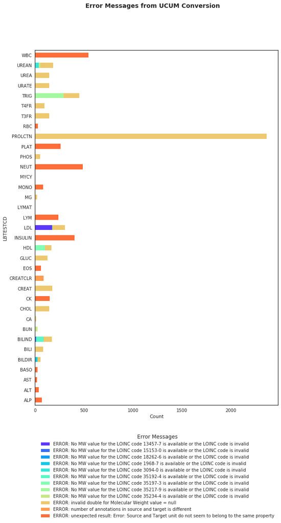

```python
fig1 = plt.figure( figsize=(10,10))
sns.set_palette("rainbow", 13)
ax4 = errormsg.pivot('LBTESTCD','RESPONSE','COUNT').plot(kind='barh',figsize=(10,15),stacked=True)
plt.legend(title='Error Messages',loc=5, bbox_to_anchor=(1, -0.2))
plt.suptitle('Error Messages from UCUM Conversion', fontsize=14, fontweight='bold')
plt.xlabel("Count")
```

```python
ucumfail.dropna(subset=['response']).to_csv('errors.csv')
```

#### Summary of Error Message finding

```python
msglist=list(set(ucumfail['response']))
for i in range(len(msglist)):

    e_=ucumfail['response']==msglist[i]
    o_=ucumfail[e_][['LBTESTCD','LBORRESU','LBSTRESU','checklist','response']].drop_duplicates(subset=['LBTESTCD','LBORRESU','LBSTRESU'])
    print('Error: '+msglist[i])
    print('Call:  '+o_['checklist'])
    print()
    print(o_[['LBTESTCD','LBORRESU','LBSTRESU']])
    print()
    print('---------------------------------------------------------------------------------------')
```

```
Error: ERROR: No MW value for the LOINC code 35192-4 is available or the LOINC code is invalid
3311    Call:  http://xml4pharmaserver.com:8080/UCUMService2/rest/ucumtransform/1.07/from/mg/dL/to/umol/L/LOINC/35192-4
Name: checklist, dtype: object

     LBTESTCD LBORRESU LBSTRESU
3311   BILIND    mg/dL   umol/L

---------------------------------------------------------------------------------------
Error: ERROR: No MW value for the LOINC code 35234-4 is available or the LOINC code is invalid
3108    Call:  http://xml4pharmaserver.com:8080/UCUMService2/rest/ucumtransform/12/from/mg/dL/to/mmol/L/LOINC/35234-4
3498     Call:  http://xml4pharmaserver.com:8080/UCUMService2/rest/ucumtransform/6/from/mg/dL/to/mmol/L/LOINC/35234-4
Name: checklist, dtype: object

     LBTESTCD LBORRESU LBSTRESU
3108    UREAN    mg/dL   mmol/L
3498      BUN    mg/dL   mmol/L

---------------------------------------------------------------------------------------
Error: ERROR: No MW value for the LOINC code 35217-9 is available or the LOINC code is invalid
3503    Call:  http://xml4pharmaserver.com:8080/UCUMService2/rest/ucumtransform/42/from/mg/dL/to/mmol/L/LOINC/35217-9
Name: checklist, dtype: object

     LBTESTCD LBORRESU LBSTRESU
3503     TRIG    mg/dL   mmol/L

---------------------------------------------------------------------------------------
Error: ERROR: number of annotations in source and target is different
15396    Call:  http://xml4pharmaserver.com:8080/UCUMService2/rest/ucumtransform/121/from/mL/min/%7B1.73_m2%7D/to/mL/s
Name: checklist, dtype: object

       LBTESTCD              LBORRESU LBSTRESU
15396  CREATCLR  mL/min/%7B1.73_m2%7D     mL/s

---------------------------------------------------------------------------------------
Error: ERROR: invalid double for Molecular Weight value = null
212        Call:  http://xml4pharmaserver.com:8080/UCUMService2/rest/ucumtransform/0.3/from/mg/dL/to/umol/L
213       Call:  http://xml4pharmaserver.com:8080/UCUMService2/rest/ucumtransform/0.73/from/mg/dL/to/umol/L
215        Call:  http://xml4pharmaserver.com:8080/UCUMService2/rest/ucumtransform/109/from/mg/dL/to/mmol/L
216        Call:  http://xml4pharmaserver.com:8080/UCUMService2/rest/ucumtransform/5.5/from/mg/dL/to/umol/L
217         Call:  http://xml4pharmaserver.com:8080/UCUMService2/rest/ucumtransform/23/from/mg/dL/to/mmol/L
```

[output cut: 109 more lines]

```
1929    Call:  http://xml4pharmaserver.com:8080/UCUMService2/rest/ucumtransform/0.1/from/mg/dL/to/umol/L/LOINC/1968-7
Name: checklist, dtype: object

     LBTESTCD LBORRESU LBSTRESU
1929   BILDIR    mg/dL   umol/L

---------------------------------------------------------------------------------------
Error: ERROR: No MW value for the LOINC code 13457-7 is available or the LOINC code is invalid
3501    Call:  http://xml4pharmaserver.com:8080/UCUMService2/rest/ucumtransform/103/from/mg/dL/to/mmol/L/LOINC/13457-7
Name: checklist, dtype: object

     LBTESTCD LBORRESU LBSTRESU
3501      LDL    mg/dL   mmol/L

---------------------------------------------------------------------------------------
```

```python
pd.options.display.max_colwidth =150
```